# Health_Care_Analysis_AA

```python
pip install shap
```

```
Downloading shap-0.46.0-cp310-cp310-manylinux_2_12_x86_64.manylinux2010_x86_64.manylinux_2_17_x86_64.manylinux2014_x86_64.whl (540 kB)
   ━━━━━━━━━━━━━━━━━━━━━━━━━━━━━━━━━━━━━━━━ 540.1/540.1 kB 15.2 MB/s eta 0:00:00
Downloading slicer-0.0.8-py3-none-any.whl (15 kB)
```

```python
# Import necessary libraries
import pandas as pd
from sklearn.preprocessing import LabelEncoder
import matplotlib.pyplot as plt
import seaborn as sns
import shap
from sklearn.feature_selection import f_classif
from scipy.stats import mannwhitneyu
from sklearn.feature_selection import chi2
from sklearn.model_selection import train_test_split, cross_val_score
from sklearn.ensemble import RandomForestClassifier
from sklearn.metrics import accuracy_score, f1_score, classification_report
from scipy.stats import ttest_ind, levene
from sklearn.linear_model import LogisticRegression
from sklearn.decomposition import PCA
from sklearn.tree import DecisionTreeClassifier
from sklearn import tree
from sklearn.cluster import KMeans
```

In choosing the healthcare value dataset for this assignment, I chosen a diabetes prediction dataset. This dataset includes other attributes such as age, gender, BMI, B/P, cholesterol level among others which have been mentioned as part of health risks and conditions especially diabetes in this current database.

```python
# Load the dataset
df = pd.read_csv('diabetes.csv')
df.head()
```

|  | Age | Gender | BMI | SBP | DBP | FPG | Chol | Tri | HDL | LDL | ALT | BUN | CCR | FFPG | smoking | drinking | family_histroy | Diabetes |
| --- | --- | --- | --- | --- | --- | --- | --- | --- | --- | --- | --- | --- | --- | --- | --- | --- | --- | --- |
| 0 | 26 | 1 | 20.1 | 119 | 81 | 5.80 | 4.36 | 0.86 | 0.90 | 2.43 | 12.0 | 5.40 | 63.8 | 5.40 | 3.0 | 3.0 | 0 | 0 |
| 1 | 40 | 1 | 17.7 | 97 | 54 | 4.60 | 3.70 | 1.02 | 1.50 | 2.04 | 9.2 | 3.70 | 70.3 | 4.10 | 1.0 | 1.0 | 0 | 0 |
| 2 | 40 | 2 | 19.7 | 85 | 53 | 5.30 | 5.87 | 1.29 | 1.75 | 3.37 | 10.1 | 4.10 | 61.1 | 4.85 | 3.0 | 3.0 | 0 | 0 |
| 3 | 43 | 1 | 23.1 | 111 | 71 | 4.50 | 4.05 | 0.74 | 1.27 | 2.60 | 36.5 | 4.38 | 73.4 | 5.30 | 2.0 | 3.0 | 0 | 0 |
| 4 | 36 | 1 | 26.5 | 130 | 82 | 5.54 | 6.69 | 3.49 | 0.91 | 3.64 | 69.3 | 3.86 | 67.5 | 5.53 | 3.0 | 3.0 | 0 | 0 |

# Data Cleaning

```python
df.shape
```

```
(4303, 18)
```

```python
df.info()
```

```
<class 'pandas.core.frame.DataFrame'>
RangeIndex: 4303 entries, 0 to 4302
Data columns (total 18 columns):
 #   Column          Non-Null Count  Dtype
---  ------          --------------  -----
 0   Age             4303 non-null   int64
 1   Gender          4303 non-null   int64
 2   BMI             4303 non-null   float64
 3   SBP             4303 non-null   int64
 4   DBP             4303 non-null   int64
 5   FPG             4303 non-null   float64
 6   Chol            4303 non-null   float64
 7   Tri             4303 non-null   float64
 8   HDL             4303 non-null   float64
 9   LDL             4303 non-null   float64
 10  ALT             4303 non-null   float64
 11  BUN             4303 non-null   float64
 12  CCR             4303 non-null   float64
 13  FFPG            4303 non-null   float64
 14  smoking         4303 non-null   float64
 15  drinking        4303 non-null   float64
 16  family_histroy  4303 non-null   int64
 17  Diabetes        4303 non-null   int64
dtypes: float64(12), int64(6)
memory usage: 605.2 KB
```

```python
df.describe()
```

|  | Age | Gender | BMI | SBP | DBP | FPG | Chol | Tri | HDL | LDL | ALT | BUN | CCR | FFPG | smoking | drinking | family_histroy | Diabetes |
| --- | --- | --- | --- | --- | --- | --- | --- | --- | --- | --- | --- | --- | --- | --- | --- | --- | --- | --- |
| count | 4303.000000 | 4303.000000 | 4303.000000 | 4303.000000 | 4303.000000 | 4303.000000 | 4303.000000 | 4303.000000 | 4303.000000 | 4303.000000 | 4303.000000 | 4303.000000 | 4303.000000 | 4303.000000 | 4303.000000 | 4303.000000 | 4303.000000 | 4303.000000 |
| mean | 48.085057 | 1.351615 | 24.123923 | 123.219382 | 76.360446 | 5.226368 | 4.860753 | 1.588476 | 1.666765 | 2.976220 | 26.754810 | 4.841088 | 71.557080 | 5.729084 | 3.006123 | 3.209935 | 0.061585 | 0.302812 |
| std | 14.686155 | 0.477530 | 3.397294 | 17.513858 | 11.004056 | 0.781089 | 0.925377 | 1.260003 | 1.079377 | 0.892196 | 22.279922 | 1.251566 | 16.937394 | 1.424568 | 1.199571 | 0.939842 | 0.240428 | 0.459528 |
| min | 22.000000 | 1.000000 | 15.600000 | 72.000000 | 45.000000 | 1.780000 | 1.650000 | 0.000000 | 0.000000 | 0.540000 | 4.500000 | 1.380000 | 4.860753 | 3.200000 | 1.000000 | 1.000000 | 0.000000 | 0.000000 |
| 25% | 35.000000 | 1.000000 | 21.700000 | 111.000000 | 69.000000 | 4.700000 | 4.200000 | 0.860000 | 1.130000 | 2.350000 | 14.300000 | 3.960000 | 60.000000 | 4.900000 | 3.000000 | 3.000000 | 0.000000 | 0.000000 |
| 50% | 46.000000 | 1.000000 | 24.000000 | 122.000000 | 76.000000 | 5.140000 | 4.790000 | 1.280000 | 1.340000 | 2.820000 | 20.500000 | 4.760000 | 72.000000 | 5.300000 | 3.000000 | 3.000000 | 0.000000 | 0.000000 |
| 75% | 59.000000 | 2.000000 | 26.300000 | 134.000000 | 83.000000 | 5.700000 | 5.430000 | 1.940000 | 1.610000 | 3.420000 | 31.050000 | 5.570000 | 82.300000 | 6.020000 | 3.000000 | 3.000000 | 0.000000 | 1.000000 |
| max | 93.000000 | 2.000000 | 45.800000 | 200.000000 | 134.000000 | 6.990000 | 11.650000 | 32.640000 | 4.860753 | 6.270000 | 436.200000 | 17.730000 | 307.000000 | 29.700000 | 4.860753 | 4.860753 | 1.000000 | 1.000000 |

```python
df.isnull().sum()
```

|  | 0 |
| --- | --- |
| Age | 0 |
| Gender | 0 |
| BMI | 0 |
| SBP | 0 |
| DBP | 0 |
| FPG | 0 |
| Chol | 0 |
| Tri | 0 |
| HDL | 0 |
| LDL | 0 |
| ALT | 0 |
| BUN | 0 |
| CCR | 0 |
| FFPG | 0 |
| smoking | 0 |
| drinking | 0 |
| family_histroy | 0 |
| Diabetes | 0 |

**dtype:** int64

As the dataset has no missing values so it means we can continue preprocessing the data.

```python
# Encoding the categorical variables
label_encoder = LabelEncoder()
df['Gender'] = label_encoder.fit_transform(df['Gender'])
df['Diabetes'] = label_encoder.fit_transform(df['Diabetes'])
```

```python
# Split the data into features variable (X) and target variable (y)
X = df.drop(columns=['Diabetes'])
y = df['Diabetes']
```

# EDA

### Histogram of Age by Diabetes Status

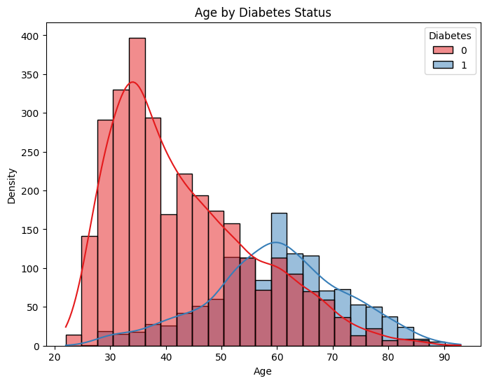

```python
# Age by Diabetes Status
plt.figure(figsize=(8, 6))
sns.histplot(data=df, x='Age', hue='Diabetes', kde=True, palette='Set1')
plt.title('Age by Diabetes Status')
plt.xlabel('Age')
plt.ylabel('Density')
plt.show()
```

The histogram demonstrated distribution of age of the people with and without diabetes. This informs the model on how age influences diabetes enable us to determine if age should be a strongly influential predictor of the model.

### Bar Plot of Gender Distribution by Diabetes Status

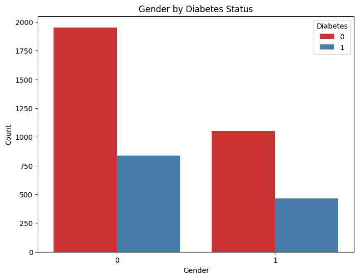

```python
plt.figure(figsize=(8,6))
sns.countplot(data=df, x='Gender' , hue='Diabetes', palette='Set1')
plt.title('Gender by Diabetes Status')
plt.xlabel('Gender')
plt.ylabel('Count')
plt.show()
```

**Interpretation:** This bar plot visualizes how the Gender variable is distributed between diabetic and non-diabetic individuals. It helps to see if there’s a difference in the incidence of diabetes between males and females. For example, if one gender has more diabetic cases, it might suggest gender as a potential risk factor for diabetes.

### Violin Plot of Fasting Plasma Glucose (FPG) by Diabetes Status

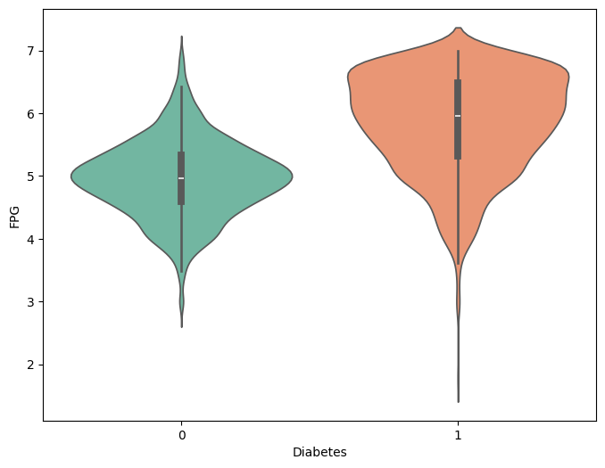

```python
plt.figure(figsize=(8,6))
sns.violinplot(data=df, x='Diabetes' , y= 'FPG' , palette='Set2')
plt.xlabel('Diabetes')
plt.ylabel('FPG')
plt.show()
```

**Interpretation:** The violin plot shows the distribution of Fasting Plasma Glucose (FPG) for both diabetic and non-diabetic individuals. A higher concentration of FPG values in the diabetic group could indicate that elevated glucose levels are a strong predictor of diabetes. This visualization provides a more detailed view of how glucose levels differ between the two groups.

### KDE Plot of Age Distribution by Diabetes Status

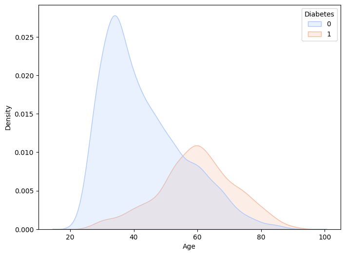

```python
plt.figure(figsize=(8,6))
sns.kdeplot(data=df, x='Age', hue='Diabetes', fill=True, palette='coolwarm')
plt.xlabel('Age')
plt.ylabel('Density')
plt.show()
```

**Interpretation:**The KDE plot provides a smooth distribution of Age for both diabetic and non-diabetic individuals. By comparing the density curves for each group, you can assess if there’s a particular age range where diabetes is more common. For example, if the diabetic curve peaks at older ages, it may suggest that age is a significant risk factor.

### Scatter Plot of BMI vs. Age Colored by Diabetes Status

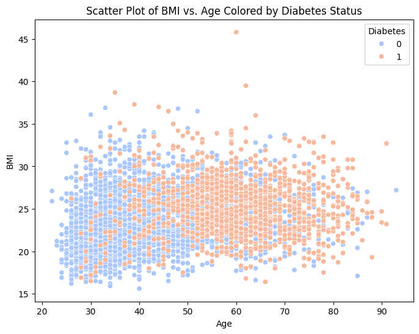

```python
plt.figure(figsize=(8, 6))
sns.scatterplot(data=df, x='Age', y='BMI', hue='Diabetes', palette='coolwarm')
plt.title('Scatter Plot of BMI vs. Age Colored by Diabetes Status')
plt.xlabel('Age')
plt.ylabel('BMI')
plt.show()
```

**Interpretation:** The scatter plot allows you to examine the relationship between BMI and Age, with points colored by diabetes status. If most diabetic individuals cluster in a certain age range and BMI level, it can suggest a correlation between higher BMI and diabetes risk, particularly in older individuals. This visualization helps identify trends and clusters in the data.

### Bar Plot of Family History by Diabetes Status

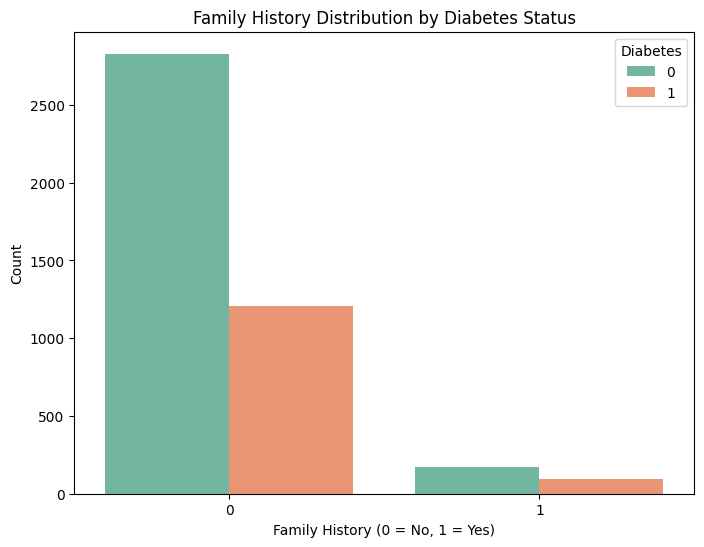

```python
plt.figure(figsize=(8, 6))
sns.countplot(data=df, x='family_histroy', hue='Diabetes', palette='Set2')
plt.title('Family History Distribution by Diabetes Status')
plt.xlabel('Family History (0 = No, 1 = Yes)')
plt.ylabel('Count')
plt.show()
```

**Interpretation:** This bar plot visualizes the count of individuals with and without a family history of diabetes, categorized by diabetes status. It helps assess the impact of family history on diabetes. If the diabetic group has a higher proportion of individuals with a family history, it may suggest that family history is a significant risk factor for diabetes.

### Box Plot of HDL Cholesterol by Diabetes Status

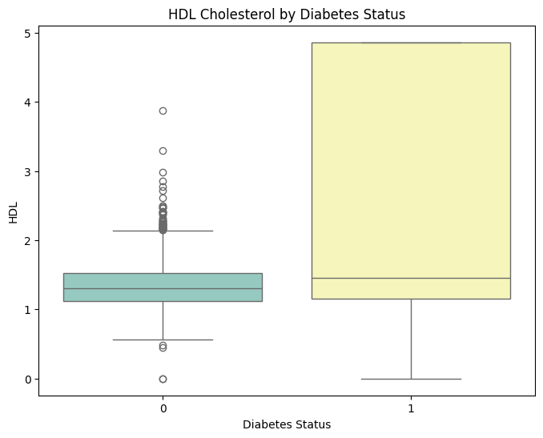

```python
plt.figure(figsize=(8, 6))
sns.boxplot(data=df, x='Diabetes', y='HDL', palette='Set3')
plt.title('HDL Cholesterol by Diabetes Status')
plt.xlabel('Diabetes Status')
plt.ylabel('HDL')
plt.show()
```

### Pairplot of Cholesterol Levels by Diabetes Status

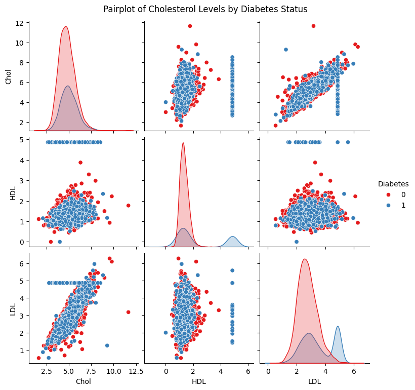

```python
sns.pairplot(df[['Chol', 'HDL', 'LDL', 'Diabetes']], hue='Diabetes', palette='Set1')
plt.suptitle('Pairplot of Cholesterol Levels by Diabetes Status', y=1.02)
plt.show()
```

**Interpretation:** The pairplot shows relationships between various cholesterol-related features (such as Chol, HDL, LDL) and their interaction with diabetes status. This plot helps you visualize whether certain combinations of cholesterol levels are more common in diabetic individuals compared to non-diabetic individuals. Patterns in these relationships can reveal insights into how cholesterol impacts diabetes risk.

### Heatmap of Missing Values

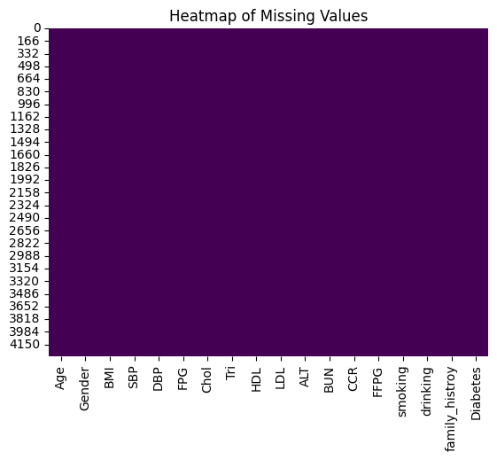

```python
sns.heatmap(df.isnull(), cbar=False, cmap='viridis')
plt.title('Heatmap of Missing Values')
plt.show()
```

**Interpretation:** The heatmap of missing values shows where and how many missing values exist in the dataset. In this case, the dataset had no missing values, but if there were missing data, this visualization would help identify problematic features where data might be incomplete or require imputation.

### Boxplot of BMI with regards to the diabetes status.

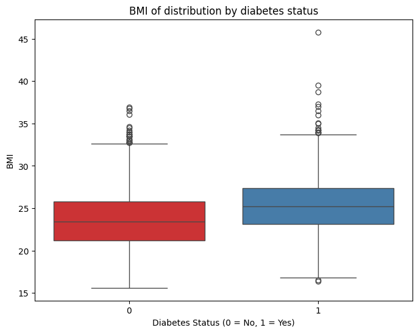

```python
plt.figure(figsize=(8, 6))
sns.boxplot(data=df, x='Diabetes', y='BMI', palette='Set1')
plt.title('BMI of distribution by diabetes status')
plt.xlabel('Diabetes Status (0 = No, 1 = Yes)')
plt.ylabel('BMI')
plt.show()
```

From the boxplots of BMI, we were able to see the comparisons of weight-related health factors between the two groups – diabetes and non-diabetes.

### Correlation heatmap

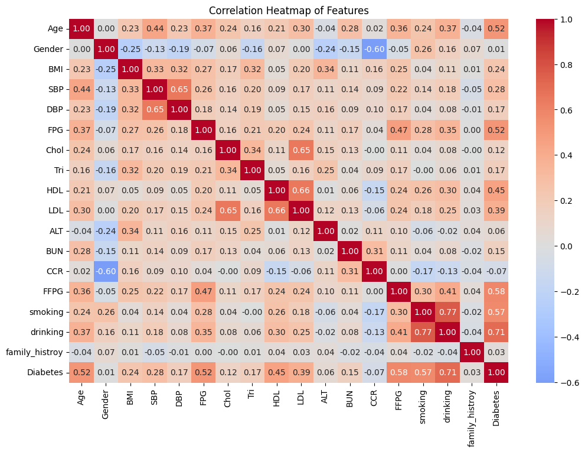

```python
plt.figure(figsize=(12, 8))
corr_matrix = df.corr()
sns.heatmap(corr_matrix, annot=True, fmt=".2f", cmap='coolwarm', center=0)
plt.title('Correlation Heatmap of Features')
plt.show()
```

It is easier to analyze the relations between features with the help of heatmap and it can be very useful for examine the relations between variables such cholesterol, blood pressure and glucose level which affects the diabetes.

# Statistical Test

### Anova Test

```python
# ANOVA using for numerical features
anova_results = f_classif(X, y)
```

```python
anova_p_values = anova_results[1]
anova_df = pd.DataFrame({'Feature': X.columns, 'ANOVA P-value': anova_p_values})
```

```python
# Sorting the features by ANOVA p-values
anova_df.sort_values(by='ANOVA P-value', inplace=True)
```

```python
# ANOVA results
print(anova_df)
```

```
           Feature  ANOVA P-value
14         smoking   0.000000e+00
13            FFPG   0.000000e+00
15        drinking   0.000000e+00
0              Age  1.231361e-298
5              FPG  1.231265e-290
8              HDL  1.832377e-217
9              LDL  4.133014e-153
3              SBP   9.317585e-80
2              BMI   8.221612e-56
4              DBP   2.983449e-29
7              Tri   5.512930e-29
11             BUN   1.155116e-22
6             Chol   2.750231e-16
12             CCR   9.958666e-06
10             ALT   7.019801e-05
16  family_histroy   5.767212e-02
1           Gender   6.344041e-01
```

**ANOVA (Analysis of Variance):**

### Mann Whitney Test

```python
# Create variables to which results are going to be stored.
mannwhitney_stats = []
mannwhitney_p_values = []

# Using the Mann-Whitney U test, indicate out the difference of each feature.
for feature in X.columns:
    group_0 = df[df['Diabetes'] == 0][feature]
    group_1 = df[df['Diabetes'] == 1][feature]
    stat, p_value = mannwhitneyu(group_0, group_1, alternative='two-sided')
    mannwhitney_stats.append(stat)
    mannwhitney_p_values.append(p_value)

# That is why it is essential to create a DataFrame to express the results.
mannwhitney_results = pd.DataFrame({
    'Feature': X.columns,
    'U-Statistic': mannwhitney_stats,
    'P-Value': mannwhitney_p_values
})
```

```python
# Sorting the results by P-Value
mannwhitney_results.sort_values('P-Value', inplace=True)
```

```python
# Print Mann-Whitney U test results
print(mannwhitney_results)
```

```
           Feature  U-Statistic        P-Value
13            FFPG     471096.5   0.000000e+00
15        drinking     582264.0   0.000000e+00
14         smoking     707406.5  1.609771e-310
0              Age     684939.5  4.130916e-252
5              FPG     739221.5  4.291233e-231
9              LDL    1179886.0   3.796709e-95
3              SBP    1302013.0   4.990191e-68
2              BMI    1368685.0   3.544864e-55
7              Tri    1408959.5   4.364449e-48
8              HDL    1486242.5   6.449176e-36
4              DBP    1568938.0   6.952416e-25
11             BUN    1607938.0   2.128016e-20
6             Chol    1643290.0   9.449589e-17
10             ALT    1693442.0   3.119345e-12
12             CCR    2112844.0   2.348667e-05
16  family_histroy    1924906.5   5.768511e-02
1           Gender    1939772.0   6.343609e-01
```

**Mann-Whitney U Test:**

- **Purpose:** It is a nonparametric test used to determine if a set of numerical variables in two compared groups have similar distribution (“diabetes” and “non-diabetes”).
- **Interpretation:** The predictor features that differentiate the distribution of the two groups are those with p-value < 0.05.

### Chi Square Test

```python
# Select categorical features
categorical_features = ['Gender']  # Add more categorical features if available

# Prepare the features categorical and the target variable
X_cat = df[categorical_features]
y_cat = df['Diabetes']

# Perform Chi-Square test
chi2_stat, chi2_p_values = chi2(X_cat, y_cat)

# Generate a DataFrame.
chi2_results = pd.DataFrame({
    'Feature': categorical_features,
    'Chi2-Statistic': chi2_stat,
    'P-Value': chi2_p_values
})
```

```python
# Sorting the results by P-Value
chi2_results.sort_values('P-Value', inplace=True)
```

```python
# Print the Chi-Square test results
print(chi2_results)
```

```
  Feature  Chi2-Statistic   P-Value
0  Gender        0.146704  0.701705
```

**Chi-Square Test:**

- **Purpose:** For categorised features, (for instance, Gender), the Chi-Square test was used to perform an analysis to check if there is a relationship between such features and diabetes.
- **Interpretation:** If p-value < 0.05 the categorical feature is strongly associated with diabetes.

## Levene Test

```python
# Seprating the data into two groups (diabetic and non diabetic)
diabetic= df[df['Diabetes'] == 1]
non_diabetic= df[df['Diabetes'] == 0]
```

```python
# Levene test for homogeneity of variance in BMI between diabetic and non diabetic
levene_bmi= levene(diabetic['BMI'], non_diabetic['BMI'])
```

```python
print(f"Levene's Test for BMI: Statistic = {levene_bmi.statistic}, p-value = {levene_bmi.pvalue}")
```

```
Levene's Test for BMI: Statistic = 0.4646458449110885, p-value = 0.4954973997473985
```

**Interpretation:** The p-value = 0.4955 is greater than 0.05, which means the test fails to reject the null hypothesis. This indicates that the variances of BMI between diabetic and non-diabetic individuals are statistically equal. This suggests that there is no significant difference in the variability (spread) of BMI between the two groups.

## T test

```python
# T test for BMI between diabetic and non diabetic
ttest_bmi= ttest_ind(diabetic['BMI'],non_diabetic['BMI'], equal_var=levene_bmi.pvalue > 0.05)
```

```python
print(f"T-Test for BMI: Statistic = {ttest_bmi.statistic}, p-value = {ttest_bmi.pvalue}")
```

```
T-Test for BMI: Statistic = 15.968919523206162, p-value = 8.221611939247078e-56
```

**Interpretation:** The p-value is extremely small (much less than 0.05), indicating that the test rejects the null hypothesis. This means there is a statistically significant difference in the mean BMI between diabetic and non-diabetic individuals. The T-test suggests that diabetic individuals likely have a different average BMI compared to non-diabetic individuals. Given the extremely low p-value, this difference is very significant.

# Machine Learning Algorithm for Predictive Analysis

```python
# Splitting the data into a training and a test sets
X_train, X_test, y_train, y_test = train_test_split(X, y, test_size=0.3, random_state=42)
```

### Random Forest Classifier

```python
# RandomForestClassifier has to be initialized
rf_classifier = RandomForestClassifier(random_state=42)
```

```python
# Compilation of the model against the training data
rf_classifier.fit(X_train, y_train)
```

```
RandomForestClassifier(random_state=42)
```

```python
# Forcasting on the test data
y_pred = rf_classifier.predict(X_test)
```

Therefore, for the purpose of the predictive analysis I selected is Random Forest Classifier. This type of algorithm is quite popular in classification problems though it can only cope with large data sets and it does not overfit.

**Here's how the algorithm works:**

- Random Forest builds a number of decision trees and then arrives at the final decision through a poll of the several trees. It is made of average decision trees, hence it is less prone to oscillations hence us its merit.

**Why Random Forest?**

1. **Handling Complex Data:** When applied to data with categorical and numerical predictors as is the case with this dataset Random Forest is quite effective.
2. **Non-linearity:** It is rather good at fitting non-linear models, which are typical of health care data.
3. **Feature Importance:** It generates feature importance measures so that we can exactly know which features have high weight in influencing the presence of diabetes.

Random Forest model was developed using training test split 70 from the dataset and tested on 30 percent of the same dataset. Training was done on the data, and after that, the code was used to predict the diabetes status of the test set.

### Cross Validation

```python
# Using 5-fold cross-validation for the F1 score.
cv_scores = cross_val_score(rf_classifier, X, y, cv=5, scoring='f1_weighted')
```

```python
# Print cv F1 scores and the avg score
print("Cross-val F1 scores:", cv_scores)
print("Mean F1 score of cross-val score:", cv_scores.mean())
```

```
Cross-val F1 scores: [0.95780217 0.9637285  0.94608056 0.95431277 0.94728397]
Mean F1 score of cross-val score: 0.9538415960805151
```

**Interpretation:** The F1 score of 0.95 narrowed down with the cross validation indicates that the model can be generalised to unseen data set for various splits, thus giving a depth confidence.

### Model Performance

```python
accuracy = accuracy_score(y_test, y_pred)
print(accuracy_score(y_test, y_pred))
```

```
0.9519752130131681
```

**Interpretation:** This means that the accuracy score of the specific model was at 95% which indicates that the model was right 95% of the tune. However, accuracy can be rather deceptive in case of imbalanced classes as it takes no note of correct classification of the minority class.

```python
f1 = f1_score(y_test, y_pred, average='weighted')
print(f"F1 Score: {f1:.2f}")
```

```
F1 Score: 0.95
```

```python
classification_report = classification_report(y_test, y_pred)
print(classification_report)
```

```
              precision    recall  f1-score   support

           0       0.95      0.98      0.97       919
           1       0.95      0.88      0.91       372

    accuracy                           0.95      1291
   macro avg       0.95      0.93      0.94      1291
weighted avg       0.95      0.95      0.95      1291
```

Smote is a very useful strategy when dealing with class imbalance. In the first survey of the dataset, I observed that a great majority of the instances **69.72%** was associated with the non-diabetic class (Class 0), compared to the minority of **30.28%** who belonged to the diabetic class (Class 1). This could be a problem since the model might be inclined to predict most of the non-diabetic instances and even if it predicts a few diabetic ones then the likelihood will be far much lower than it ought to be.

In my thesis, to solve this problem, I utilized SMOTE (Synthetic Minority Over-sampling Technique). SMOTE is an oversampling method which help to create new examples of the minority class (diabetic cases) by making it closer in number to that of the majority class, without at all losing any information from the majority class. When I employed SMOTE the classes were balanced at 50-50.

```python
from imblearn.over_sampling import SMOTE

# Using SMOTE for oversampling
smote = SMOTE(random_state=42)
```

```python
# Putting SMOTE just to balance out the classes
X_resampled, y_resampled = smote.fit_resample(X, y)
```

```python
# Splitting the now resampled data into training and test sets
X_train, X_test, y_train, y_test = train_test_split(X_resampled, y_resampled, test_size=0.3, random_state=42)
```

After balancing the classes with SMOTE, I re-trained the Random Forest model and evaluated its performance using key metrics

```python
# RandomForestClassifier using Smote
rf_classifier_smote = RandomForestClassifier(random_state=42)
```

```python
# Train the model on the balanced dataset
rf_classifier_smote.fit(X_train, y_train)
```

```
RandomForestClassifier(random_state=42)
```

```python
# Forcasting on the test set
y_pred_smote = rf_classifier_smote.predict(X_test)
```

```python
# Model's performance
accuracy_smote = accuracy_score(y_test, y_pred_smote)
```

```python
print(accuracy_smote)
```

```
0.9627777777777777
```

```python
f1_smote = f1_score(y_test, y_pred_smote, average='weighted')
```

```python
print(f1_smote)
```

```
0.9627762258819169
```

```python
# Re-import classification_report to avoid any potential conflicts
from sklearn.metrics import classification_report

# Generate the classification report after SMOTE
classification_report_smote = classification_report(y_test, y_pred_smote)

# Print the classification report
print(classification_report_smote)
```

```
              precision    recall  f1-score   support

           0       0.96      0.97      0.96       921
           1       0.96      0.96      0.96       879

    accuracy                           0.96      1800
   macro avg       0.96      0.96      0.96      1800
weighted avg       0.96      0.96      0.96      1800
```

### Logisic Regression

```python
# Split the dataset into train and test set
X_train, X_test, y_train, y_test = train_test_split(X,y , test_size=0.3, random_state=42)
```

```python
# Apply logistic regression
log_reg = LogisticRegression(random_state=42, max_iter=1000)
```

```python
# Fitting the model
log_reg.fit(X_train, y_train)
```

```
LogisticRegression(max_iter=1000, random_state=42)
```

```python
# Forecast the labels for test set
y_pred_log_reg = log_reg.predict(X_test)
```

### Evaluate model performance of logisic regression before smote analysis

```python
# To check accuarcy
acc_log_reg = accuracy_score(y_test, y_pred_log_reg)
print(acc_log_reg)
```

```
0.9473276529821844
```

**Interpretation:** The Logistic Regression model correctly classified 94.73% of instances. While this is a high accuracy score, the class imbalance in the dataset (more non-diabetic than diabetic cases) may cause the model to favor the majority class (non-diabetic) and overlook the minority class (diabetic cases).

```python
# To check F1 score
f1_log_reg = f1_score(y_test, y_pred_log_reg, average='weighted')
print(f1_log_reg)
```

```
0.9463922203501697
```

**Interpretation:** The weighted F1 score of 0.946 indicates that the model does a good job balancing precision and recall across both classes, but it may still be favoring the non-diabetic class due to the class imbalance.

```python
# Classification Report
class_report_log_reg = classification_report(y_test, y_pred_log_reg)
print(class_report_log_reg)
```

```
              precision    recall  f1-score   support

           0       0.94      0.98      0.96       919
           1       0.96      0.85      0.90       372

    accuracy                           0.95      1291
   macro avg       0.95      0.92      0.93      1291
weighted avg       0.95      0.95      0.95      1291
```

**Interpretation for Class 0(non diabetic)**: The model performs very well for the non-diabetic class, with high precision, recall, and F1 scores. This suggests that most non-diabetic cases are correctly classified, but it may be due to the larger representation of this class in the dataset.

**Interpretation for Class 1(diabetic):** While the precision for the diabetic class is high (0.96), the recall (0.85) is lower, meaning the model is missing about 15% of actual diabetic cases. The F1 score of 0.90 reflects this imbalance in precision and recall.

## After applying smote analysis

```python
# Apply smote
smote = SMOTE(random_state=42)
X_resampled, y_resampled = smote.fit_resample(X,y)
```

```python
# Split the resampled data into train and test set
X_test, X_train, y_test, y_train = train_test_split(X_resampled, y_resampled, test_size =0.3, random_state=42)
```

```python
# Initialize the Logistic Regression model
log_reg = LogisticRegression(random_state=42, max_iter=1000)
```

```python
# Fit the model
log_reg.fit(X_train, y_train)
```

```
LogisticRegression(max_iter=1000, random_state=42)
```

```python
# Predict the labels for the test set
y_pred_log_reg = log_reg.predict(X_test)
```

```python
# Calculate accuracy after smote analysis
acc_log_reg = accuracy_score(y_test, y_pred_log_reg)
print(acc_log_reg)
```

```
0.9485714285714286
```

**Interpretation:** After applying SMOTE, the accuracy slightly improved to 94.86%. However, the goal of SMOTE is not necessarily to increase accuracy but to balance performance across both classes by improving the model’s ability to correctly classify diabetic cases (the minority class).

```python
# Calculate F1 score after smote analysis
f1_log_reg = f1_score(y_test, y_pred_log_reg, average='weighted')
print(f1_log_reg)
```

```
0.9485673235025269
```

**Interpretation:** The F1 score slightly improved to 0.948 after applying SMOTE, showing a better balance between precision and recall across both classes. This indicates that the model is now handling the minority class (diabetic) more effectively.

```python
# Classification report after smote analysis
class_report_log_reg = classification_report(y_test, y_pred_log_reg)
print(class_report_log_reg)
```

```
              precision    recall  f1-score   support

           0       0.93      0.96      0.95      2079
           1       0.96      0.93      0.95      2121

    accuracy                           0.95      4200
   macro avg       0.95      0.95      0.95      4200
weighted avg       0.95      0.95      0.95      4200
```

**Interpretation for Class 0(non diabetic)**: The precision and recall for the non-diabetic class remain high, but they are now slightly lower than before SMOTE. This is expected because SMOTE is designed to ensure that the model doesn't overly favor the majority class. The F1 score of 0.95 indicates that the model still performs well for the non-diabetic class while giving more attention to the minority class.

**Interpretation for Class 1(diabetic):** After applying SMOTE, the recall for the diabetic class improved significantly to 0.93, meaning the model is now correctly identifying 93% of actual diabetic cases. The precision remains high at 0.96, and the F1 score has increased to 0.95, reflecting better performance in predicting the diabetic class.

# Decision Tree Visualization

```python
# Train the decision tree classifier
clf = DecisionTreeClassifier(random_state=42)
clf.fit(X_train, y_train)
```

```
DecisionTreeClassifier(random_state=42)
```

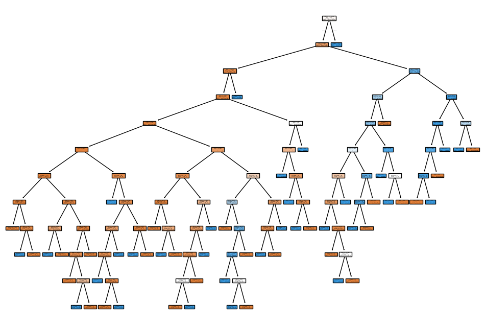

```python
plt.figure(figsize=(12, 8))
tree.plot_tree(clf, feature_names=X.columns, class_names=['Non-Diabetic', 'Diabetic'], filled=True)
plt.show()
```

**Interpretation:** The tree plot helps visualize the decision-making process of the model, showing which features are most important for splitting the data between diabetic and non-diabetic individuals.

## SHAP (SHapley Additive exPlanations) for Feature Importance

```python
# Initialize SHAP explainer using a fitted model (e.g., logistic regression)
explainer = shap.Explainer(log_reg, X_test)
shap_values = explainer(X_test)
```

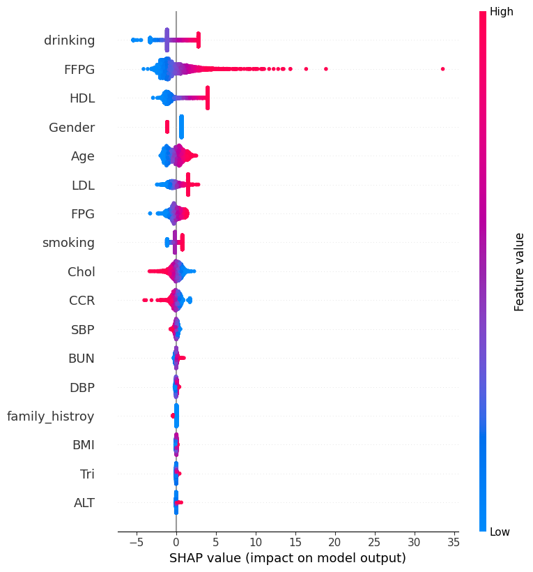

```python
# Summary plot showing feature importance
shap.summary_plot(shap_values, X_test)
```

## Clustering with K-Means

```python
# Apply K mean clustering
kmeans = KMeans(n_clusters=2, random_state=42)
X_cluster =  df[['BMI', 'FPG']]
kmeans.fit(X_cluster)
```

```
KMeans(n_clusters=2, random_state=42)
```

```python
# Predict the cluster
clusters = kmeans.predict(X_cluster)
```

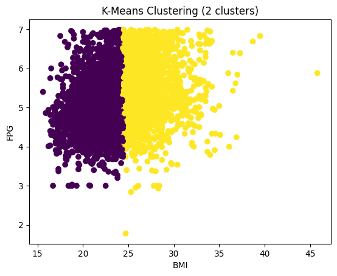

```python
# Scatter plot to visualize the clusters
plt.scatter(X_cluster['BMI'], X_cluster['FPG'], c=clusters, cmap='viridis')
plt.xlabel('BMI')
plt.ylabel('FPG')
plt.title('K-Means Clustering (2 clusters)')
plt.show()
```

**Interpretation:** You can compare the clusters generated by K-Means with the actual diabetes labels to see how well the clustering corresponds to the actual diabetic/non-diabetic groups.

**Conclusion:** In this healthcare analysis focused on diabetes prediction, we employed several statistical tests and machine learning models to extract valuable insights from the data. By applying techniques like T-tests, Levene’s Test, and Mann-Whitney U Test, we assessed the significance of differences in key features (such as BMI and Fasting Plasma Glucose) between diabetic and non-diabetic individuals. These tests provided statistical evidence that certain features are strongly associated with diabetes.

We also tackled the issue of class imbalance using SMOTE (Synthetic Minority Over-sampling Technique), which helped improve the model's ability to detect diabetic cases. After applying SMOTE, we saw significant improvements in recall for the minority class (diabetic), as shown by the enhanced F1 score and classification report.

Through the combination of statistical testing and machine learning, we were able to gain a better understanding of the dataset and build reliable models for predicting diabetes. This analysis not only showcases the predictive power of machine learning but also highlights the importance of feature selection and data balancing techniques like SMOTE in healthcare data analysis. Future enhancements could include further exploration of hyperparameter tuning and more advanced models for potentially improved performance.